# Preparing inputs

Aaron Wagen & Regina H. Reynolds

UCL

> Aim: create input files required to run LAVA

# 1 Background

To run LAVA requires that a number of files have been generated, most important of which are (i) the loci of interest (as defined based either on genomic coordinates or RS ID) and (ii) the sample overlap matrix. As described by the authors in their [pre-print](https://www.biorxiv.org/content/10.1101/2020.12.31.424652v2), loci can be defined in (i) a targeted manner (e.g. follow up of a smaller subset of loci highlighted through GWAS) or (ii) a more agnostic manner (e.g. scanning multiple traits across the entire genome). Our interest stems from (i) the pathological overlap between neurodegenerative diseases pathologically classified by the deposition of specific proteins (i.e. amyloid-$\beta$ in AD, $\alpha$-synuclein in PD and the combination of both in Lewy body dementia); (ii) the higher prevalence of depression in individuals with dementia compared to those without dementia (clinically significant in 35% of the PD population, PMID: [17987654](https://pubmed.ncbi.nlm.nih.gov/17987654/), [30536144](https://pubmed.ncbi.nlm.nih.gov/30536144/)); and (iii) the higher risk of dementia diagnoses in individuals with schizophrenia versus individuals without a history of serious mental illness (PMID: [33688938](https://pubmed.ncbi.nlm.nih.gov/33688938/), [26444987](https://pubmed.ncbi.nlm.nih.gov/26444987/)). Thus, we will begin by evaluating genome-wide significant loci from three neurodenerative disorders (Alzheimer's disease, AD; Lewy body dementia, LBD; and Parkinson's disease, PD), and three neuropsychiatric disorders (bipolar disorder, BIP; major depressive disorder, MDD; and schizophrenia, SCZ). The sample overlap matrix is important as it sample overlap can result in an upward bias of the estimated correlation.

# 2 Methods

## 2.1 Deriving loci

Genome-wide significant loci (p < 5 x $10^{-8}$) were derived from the latest publicly-available AD, BIP, LBD, MDD, PD and SCZ GWASs. Genome-wide significant loci were overlapped with LD blocks generated in the original LAVA [pre-print](https://www.biorxiv.org/content/10.1101/2020.12.31.424652v2). These LD blocks represent approximately equal sized, semi-independent blocks of SNPs, with a minimum size requirement of 2500 SNPs (resulting in an average block size of around 1Mb). The advantage of using these blocks is that the method used to derive them attempts to determine the most suitable breakpoint in a block of LD (i.e. the point at which LD is the lowest), ensuring that the LD blocks we eventually test are not "breaking" LD chunks in an inappropriate manner. Only those LD blocks containing GWAS loci were carried forward in downstream analyses.

## 2.2 Sample overlap

Due to the potential sample overlap between some GWASs and its impact on any estimated correlations, we used cross-trait LDSC ([PMID:25642630](https://pubmed.ncbi.nlm.nih.gov/25642630/); [PMID:26414676](https://pubmed.ncbi.nlm.nih.gov/26414676/)) to obtain an estimate of the sample overlap. Summary statistics for each phenotype were pre-processed using LDSC's `munge_sumstats.py` using HapMap Project Phase 3 SNPs ([PMID:20811451](https://pubmed.ncbi.nlm.nih.gov/20811451/)). For the LD reference panel, 1000 Genomes Project Phase 3 European population SNPs were used ([PMID:23128226](https://pubmed.ncbi.nlm.nih.gov/23128226/)). Any shared variance due to sample overlap was modelled as a residual genetic covariance. As described in the LAVA [pre-print](https://www.biorxiv.org/content/10.1101/2020.12.31.424652v2), genetic covariance derived from cross-trait LDSC was used to create a symmetric matrix, with diagonals populated by comparisons of each phenotype with itself. This was then converted to a correlation matrix.

# 3 Supplementary code

Following section includes any intermediary code used in this `.Rmd`.

## 3.1 Install dependencies

To run some of the scripts within this .Rmd requires packages that are not available from CRAN/Bioconductor. These include `LDSCforRyten`. If these are not already installed, run the code chunk below.

```r
devtools::install_github("RHReynolds/LDSCforRyten")
```

## 3.2 Get test loci

Note: running this script requires an internet connection, in order to load the LD blocks from from the [LAVA-partitioning](https://github.com/cadeleeuw/lava-partitioning) GitHub repository.

```r
source(here::here("scripts", "01a_get_test_loci.R"))
```

All LD blocks containing genome-wide signficiant loci are shown below.

```r
loci <-
  read_delim(
    file = here::here("results", "01_input_prep", "gwas_filtered.loci"),
    delim = "\t")

loci %>%
  DT::datatable(rownames = FALSE,
                options = list(scrollX = TRUE),
                class = 'white-space: nowrap')
```

| LOC | CHR | START | STOP |
| --- | --- | --- | --- |
| 3 | 1 | 2215496 | 2983519 |
| 10 | 1 | 7711795 | 8580987 |
| 19 | 1 | 17557747 | 18427820 |
| 30 | 1 | 30405183 | 31639217 |
| 40 | 1 | 43512670 | 45167235 |
| 44 | 1 | 49185415 | 51777577 |
| 45 | 1 | 51777578 | 53114186 |
| 52 | 1 | 59889046 | 61377615 |
| 56 | 1 | 65894185 | 66778015 |
| 57 | 1 | 66778016 | 67761890 |

[output cut: 290 more lines]

## 3.3 Get sample overlap

```r
source(here::here("scripts", "01b_get_sample_overlaps.R"))
```

Sample overlap matrix shown below.

```r
sample_overlap <-
  read.table(
    file = here::here("results", "01_input_prep", "sample_overlap.txt")
    )

sample_overlap %>%
  as.matrix()
```

```
##                         AD2019  BIP2021 LBD2020 MDD2019 PD2019.meta5.ex23andMe
## AD2019                 1.00000  0.00628 0.02589 0.01946                0.01193
## BIP2021                0.00628  1.00000 0.00800 0.05997               -0.00150
## LBD2020                0.02589  0.00800 1.00000 0.00040                0.01281
## MDD2019                0.01946  0.05997 0.00040 1.00000                0.00436
## PD2019.meta5.ex23andMe 0.01193 -0.00150 0.01281 0.00436                1.00000
## SCZ2018                0.01150  0.12928 0.00661 0.03615                0.00295
##                        SCZ2018
## AD2019                 0.01150
## BIP2021                0.12928
## LBD2020                0.00661
## MDD2019                0.03615
## PD2019.meta5.ex23andMe 0.00295
## SCZ2018                1.00000
```

## 3.4 Prepare input info file

```r
phenotypes <- c("AD2019", "LBD2020", "PD2019.meta5.ex23andMe", "BIP2021", "MDD2019", "SCZ2018") %>% sort()

gwas_details <-
  readxl::read_xlsx(path = "/data/LDScore/GWAS/LDSC_GWAS_details.xlsx") %>%
  dplyr::mutate(
    Original_name = Original_name %>%
      stringr::str_replace_all("_", "\\.")
    ) %>%
  dplyr::select(Original_name,
                cases = N_case,
                controls = N_ctrl)

input_info <-
  tibble(
    phenotype =
      list.files(
        path = gwas_dir,
        full.names = F,
        recursive = T,
        pattern = ".lava.gz"
      ) %>%
      stringr::str_remove("/.*") %>%
      stringr::str_replace_all("_", "\\."),
    filename =
      list.files(
        path = gwas_dir,
        full.names = T,
        recursive = T,
        pattern = ".lava.gz"
      )
  ) %>%
  dplyr::mutate(
    phenotype =
      case_when(phenotype == "MDD2019.ex23andMe" ~ "MDD2019",
                TRUE ~ phenotype)
  ) %>%
  dplyr::filter(phenotype %in% phenotypes) %>%
  dplyr::inner_join(
    gwas_details,
    by = c("phenotype" = "Original_name")) %>%
  # Continuous phenotypes should have cases = 1 and controls = 0
  # Continuous phenotypes will have NA in controls
  # Can use this as conditional criteria
  dplyr::mutate(
    cases =
      case_when(is.na(controls) ~ 1,
                TRUE ~ readr::parse_number(cases)),
    controls =
      case_when(is.na(controls) ~ 0,
                TRUE ~ readr::parse_number(controls))
  ) %>%
  dplyr::select(phenotype, cases, controls, filename)

write_delim(
  input_info,
  path = file.path(here::here("results", "01_input_prep"),
                   "input.info.txt"),
  delim = "\t"
)
```

Input info shown below.

```r
read_delim(
  file = file.path(here::here("results", "01_input_prep"),
                   "input.info.txt"),
  delim = "\t"
)
```

| phenotype | cases | controls | filename |
| --- | --- | --- | --- |
| AD2019 | 71880 | 383378 | /data/LDScore/GWAS/AD2019/AD_sumstats_Jansenetal_2019sept.lava.gz |
| BIP2021 | 41917 | 371549 | /data/LDScore/GWAS/BIP2021/BIP2021.lava.gz |
| LBD2020 | 2591 | 4027 | /data/LDScore/GWAS/LBD2020/LBD2020_hg19_rsids.lava.gz |
| MDD2019 | 170756 | 329443 | /data/LDScore/GWAS/MDD2019_ex23andMe/MDD2019.lava.gz |
| PD2019.meta5.ex23andMe | 33674 | 449056 | /data/LDScore/GWAS/PD2019_meta5_ex23andMe/PD2019_ex23andMe_hg19.lava.gz |
| SCZ2018 | 40675 | 64643 | /data/LDScore/GWAS/SCZ2018/SCZ2018.lava.gz |

## 3.5 Trait heritability

```r
source(here::here("scripts", "00_trait_h2.R"))
```

```r
h2 <-
  read_delim(
    here::here("results", "00_trait_h2", "h2.txt")
  )

h2
```

| phen | total_observed_scale_h2 | total_observed_scale_h2_se | lambda_gc | mean_chi_2 | intercept | intercept_se | z |
| --- | --- | --- | --- | --- | --- | --- | --- |
| AD2019 | 0.0150 | 0.0021 | 1.0864 | 1.1254 | 1.0027 | 0.0108 | 7.142857 |
| AD2019.Kunkle | 0.0713 | 0.0114 | 1.0926 | 1.1180 | 1.0302 | 0.0084 | 6.254386 |
| BIP2021 | 0.0708 | 0.0027 | 1.4530 | 1.5926 | 1.0247 | 0.0089 | 26.222222 |
| LBD2020 | 0.1711 | 0.0755 | 1.0225 | 1.0245 | 1.0020 | 0.0071 | 2.266225 |
| MDD2019 | 0.0598 | 0.0023 | 1.4530 | 1.5893 | 1.0017 | 0.0098 | 26.000000 |
| PD2019.ex23andMe.exUKBB | 0.3062 | 0.0275 | 1.0679 | 1.0928 | 0.9770 | 0.0057 | 11.134545 |
| PD2019.meta5.ex23andMe | 0.0186 | 0.0017 | 1.0895 | 1.1360 | 0.9838 | 0.0065 | 10.941176 |
| SCZ2018 | 0.4101 | 0.0138 | 1.6831 | 1.9320 | 1.0699 | 0.0113 | 29.717391 |

# 4 Results

## 4.1 Distribution of LD blocks across chromosomes

### 4.1.1 Text

- A total of 300 LD blocks were found to contain a genome-wide significant locus.
- The median block width was 1157316 base pairs, although this varied across chromosomes (Figure 4.1).
- Of the 22 possible chromosomes, 21 contained LD blocks with overlapping loci, with the highest number of LD blocks located in chromosome 1 and 6 (Figure 4.2).

### 4.1.2 Figures

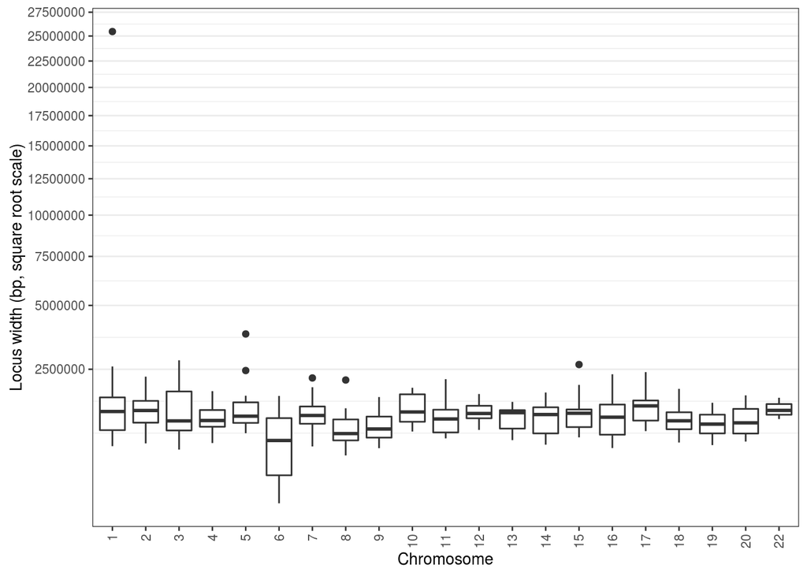

Figure 4.1: Width of LD blocks containing genome-wide significant AD, BIP, LBD, MDD, PD and SCZ loci.

```r
loci %>%
  dplyr::mutate(width = STOP - START) %>%
  ggplot(
    aes(
      x = as.factor(CHR),
      y = width)
    ) +
  geom_boxplot() +
  scale_y_sqrt(n.breaks = 10) +
  labs(x = "Chromosome",
       y = "Locus width (bp, square root scale)")
```

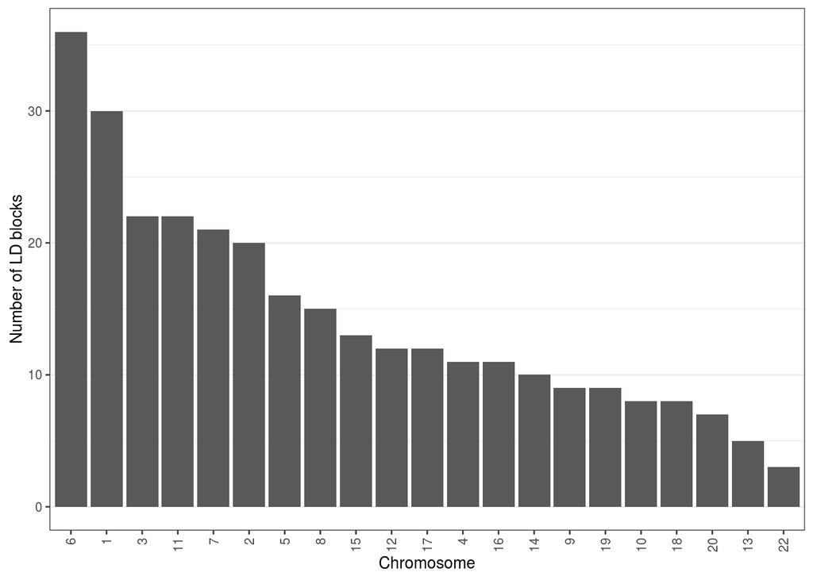

Figure 4.2: Number of LD blocks containing genome-wide significant loci per chromosome. Chromosomes have been ordered by the total number of LD blocks in each chromosome.

```r
loci %>%
  dplyr::count(CHR) %>%
  ggplot(
    aes(
      x = forcats::fct_reorder(.f = as.factor(CHR),
                               .x = n,
                               .fun = median,
                               .desc = TRUE),
      y = n)
    ) +
  geom_col() +
  labs(x = "Chromosome",
       y = "Number of LD blocks")
```

## 4.2 Distribution of genome-wide signficant SNPs across LD blocks

### 4.2.1 Text

- A total of 28333 genome-wide significant SNPs were found to overlap an LD block.
- The number of AD, BIP, LBD, MDD, PD and SCZ SNPs across LD blocks (Figure 4.3) and chromosomes (Figure 4.4) was not equally distributed. However, across most chromosomes, $\geq$ 2 neurodegenerative or neuropsychiatric traits had overlapping genome-wide significant SNPs (Figure 4.5).
- The same unequal distribution of SNPs across chromosomes was also reflected in the number of LD blocks with overlapping genome-wide significant SNPs across chromosomes (Figure 4.6).
- It is worth noting that 105 LD blocks were overlapped by $\leq$ 5 genome-wide significant SNPs.

### 4.2.2 Figures

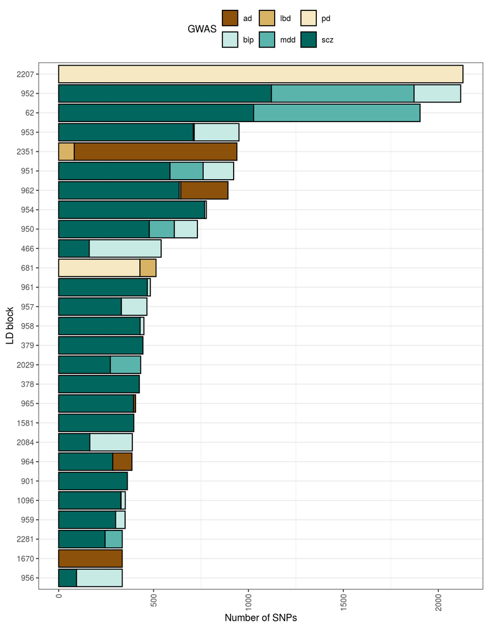

```r
gwas_loci <-
  readRDS(here::here("results", "01_input_prep", "gwas_filtered_loci.rds")) %>%
  dplyr::mutate(
    GWAS =
      fct_relevel(
          GWAS,
          c("ad", "lbd", "pd", "bip", "mdd", "scz")
        ),
    gwas_type =
      case_when(
        GWAS %in% c("ad", "lbd", "pd") ~ "neurodegenerative",
        GWAS %in% c("bip", "mdd", "scz") ~ "neuropsychiatric"
      )
  )

gwas_loci %>%
  dplyr::count(LD_CHR, LD_LOC, GWAS) %>%
  dplyr::inner_join(
    gwas_loci %>%
      dplyr::count(LD_CHR, LD_LOC, name = "n_total")
  ) %>%
  dplyr::mutate(
    LD_LOC = as.factor(LD_LOC)
  ) %>%
  dplyr::slice_max(order_by = n_total, n = 50) %>%
  ggplot(
    aes(
      x = n,
      y = forcats::fct_reorder(.f = LD_LOC,
                               .x = n,
                               .fun = sum,
                               .desc = FALSE),
      fill = GWAS)
    ) +
  geom_col(colour = "black") +
  scale_fill_brewer(
    palette = "BrBG",
    type = "div",
    name = "GWAS"
  ) +
  guides(fill = guide_legend(nrow = 2, byrow = TRUE)) +
  labs(x = "Number of SNPs",
       y = "LD block")
```

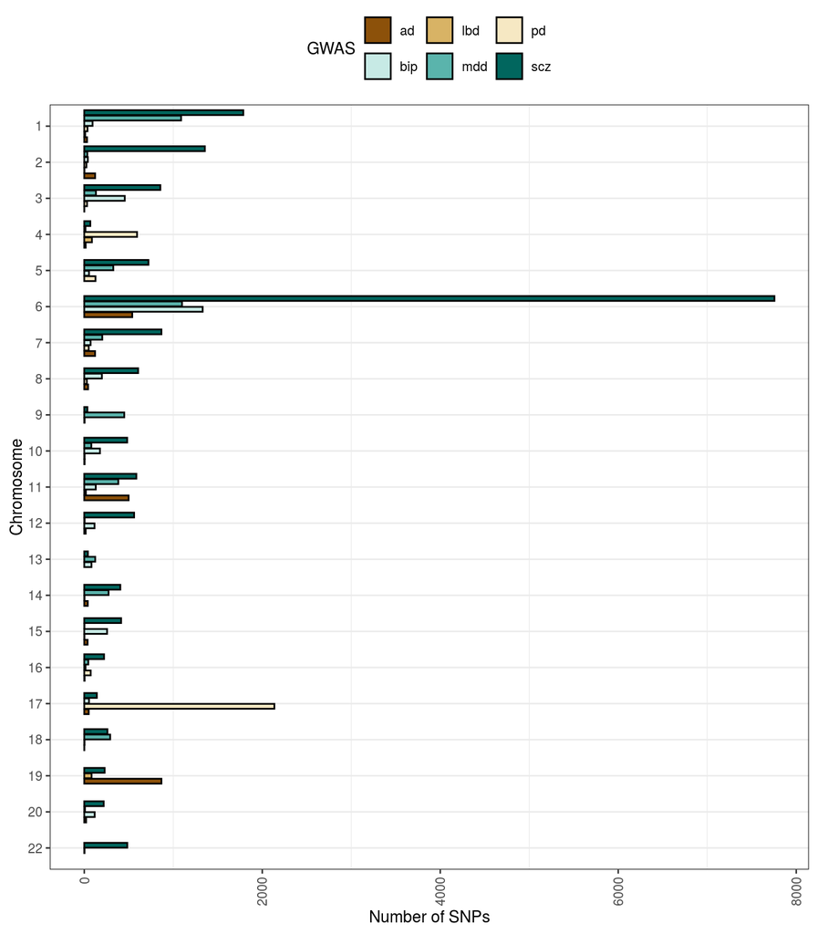

Figure 4.4: Number of genome-wide significant AD, BIP, LBD, MDD, PD and SCZ SNPs per chromosome.

```r
gwas_loci %>%
  dplyr::count(LD_CHR, GWAS) %>%
  dplyr::mutate(
    LD_CHR = as.factor(LD_CHR)
  ) %>%
  ggplot(
    aes(
      x = fct_rev(LD_CHR),
      y = n,
      fill = GWAS
    )
  ) +
  geom_col(
    position = position_dodge2(preserve = "single"),
    colour = "black"
    ) +
  scale_fill_brewer(
    palette = "BrBG",
    type = "div"
  ) +
  guides(fill = guide_legend(nrow = 2, byrow = TRUE)) +
  labs(x = "Chromosome",
       y = "Number of SNPs") +
  coord_flip()
```

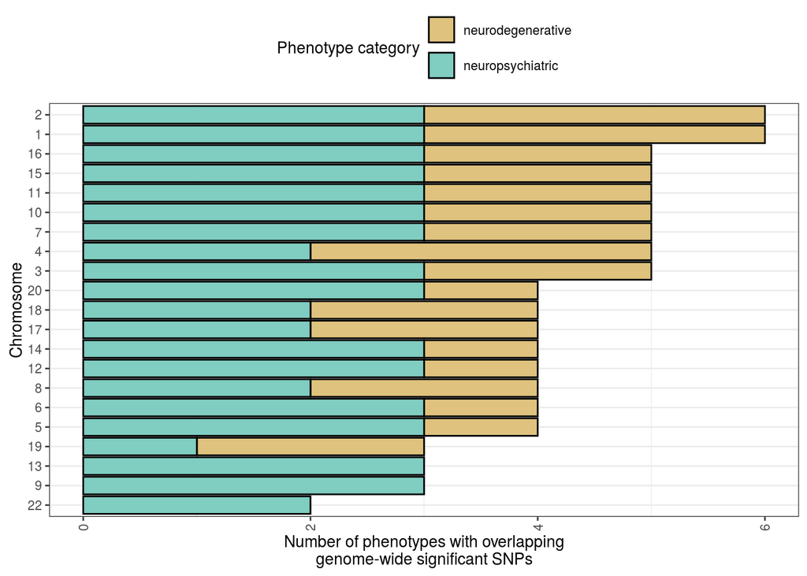

Figure 4.5: Number of phenotypes with genome-wide signficant SNPs per chromosome.

```r
gwas_loci %>%
  dplyr::distinct(LD_CHR, gwas_type, GWAS) %>%
  dplyr::count(LD_CHR, gwas_type) %>%
  dplyr::mutate(
    LD_CHR = as.factor(LD_CHR)
  ) %>%
  ggplot(
    aes(
      x = n,
      y = forcats::fct_reorder(.f = LD_CHR,
                               .x = n,
                               .fun = sum,
                               .desc = FALSE),
      fill = gwas_type)
  ) +
  geom_col(colour = "black") +
  scale_fill_manual(
    values = RColorBrewer::brewer.pal(4, name = "BrBG")[c(2,3)],
    name = "Phenotype category"
  ) +
  guides(fill = guide_legend(nrow = 2, byrow = TRUE)) +
  labs(
    x = "Number of phenotypes with overlapping\ngenome-wide significant SNPs",
    y = "Chromosome"
  )
```

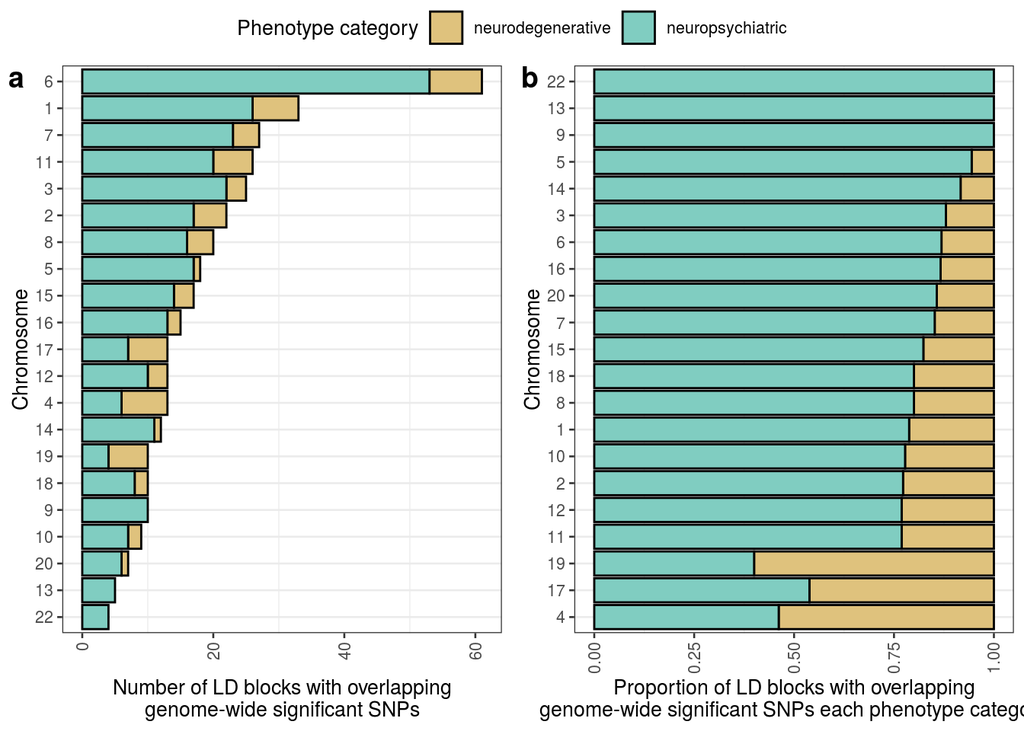

Figure 4.6: (a) Number of LD blocks with overlapping genome-wide significant SNPs per chromosome. (b) Proportion of LD blocks that are overlap genome-wide significant SNPs from a neurodegenerative or neuropsychiatric phenotype.

```r
data_to_plot <-
  gwas_loci %>%
  dplyr::distinct(LD_CHR, gwas_type, GWAS, LD_LOC) %>%
  dplyr::count(LD_CHR, gwas_type) %>%
  dplyr::mutate(
    LD_CHR = as.factor(LD_CHR)
  )

a <-
  data_to_plot %>%
  ggplot(
    aes(
      x = n,
      y = forcats::fct_reorder(.f = LD_CHR,
                               .x = n,
                               .fun = sum,
                               .desc = FALSE),
      fill = gwas_type)
  ) +
  geom_col(colour = "black") +
  scale_fill_manual(
    values = RColorBrewer::brewer.pal(4, name = "BrBG")[c(2,3)],
    name = "Phenotype category"
  ) +
  labs(
    x = "Number of LD blocks with overlapping\ngenome-wide significant SNPs",
    y = "Chromosome"
  )

b <-
  data_to_plot %>%
  dplyr::inner_join(
    data_to_plot %>%
      dplyr::group_by(LD_CHR) %>%
      dplyr::mutate(n_total = sum(n))
  ) %>%
  dplyr::mutate(
    LD_CHR = as.factor(LD_CHR),
    prop = n/n_total
  ) %>%
  ggplot(
    aes(
      x = prop,
      y = forcats::fct_reorder(.f = LD_CHR,
                               .x = prop,
                               .fun = max,
                               .desc = FALSE),
      fill = gwas_type)
  ) +
  geom_col(colour = "black") +
  scale_fill_manual(
    values = RColorBrewer::brewer.pal(4, name = "BrBG")[c(2,3)],
    name = "Phenotype category"
  ) +
  labs(
    x = "Proportion of LD blocks with overlapping\ngenome-wide significant SNPs each phenotype category",
    y = "Chromosome"
  )

ggpubr::ggarrange(
  a,b,
  labels = letters[1:2],
  align = "hv",
  common.legend = TRUE
)
```

## 4.3 Trait heritability

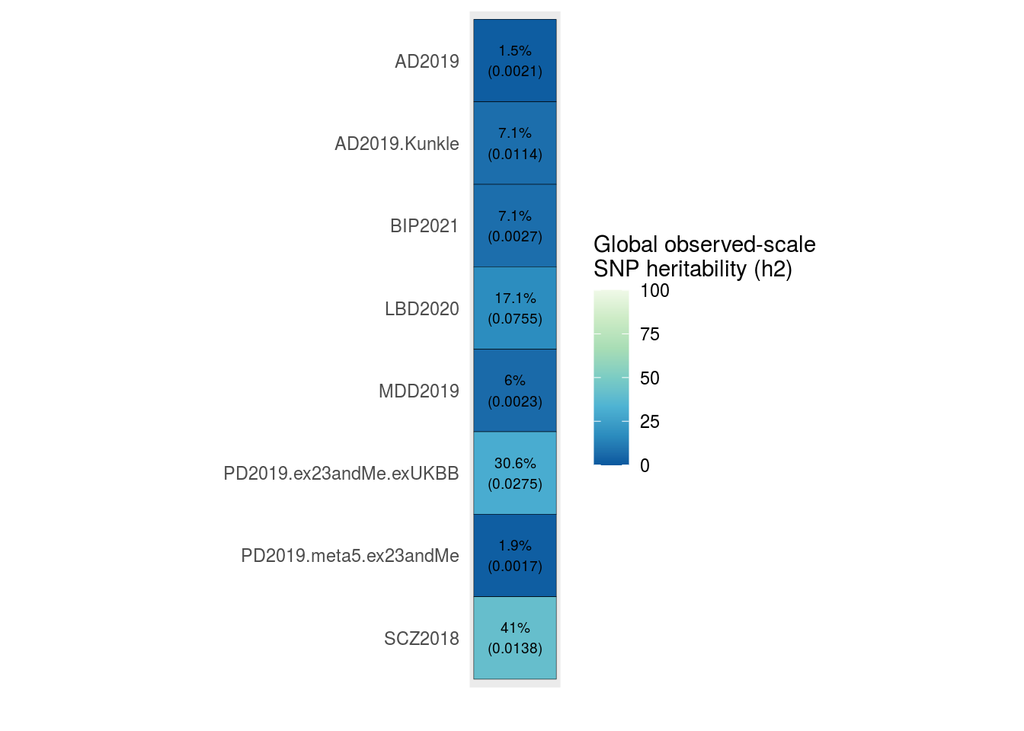

Figure 4.7: Heatmap of trait heritability, as determined by LDSC. Standard error is shown in brackets.

```r
data_to_plot <-
  h2 %>%
  dplyr::mutate(
    total_observed_scale_h2  =
      (total_observed_scale_h2 *100) %>% round(digits = 1),
    se =
      (total_observed_scale_h2_se * 100) %>% round(digits = 1),
    label =
      str_c(
        total_observed_scale_h2, "%\n(", total_observed_scale_h2_se, ")"
      )
  )

data_to_plot %>%
  ggplot(
    aes(
      x = 1,
      y = fct_rev(phen),
      fill = total_observed_scale_h2,
      label = label
    )
  ) +
  ggplot2::geom_tile(colour = "black") +
  ggplot2::geom_text(
    size = 2.5
  ) +
  ggplot2::coord_equal() +
  ggplot2::labs(x = "", y = "", fill = "Global observed-scale\nSNP heritability (h2)") +
  ggplot2::scale_fill_distiller(
    palette = "GnBu",
    limits = c(0, 100)
  ) +
  ggplot2::guides(colour = F) +
  theme_rhr +
  ggplot2::theme(
    panel.border = element_blank(),
    panel.grid = element_blank(),
    axis.ticks = element_blank(),
    axis.text.x = element_blank()
  )
```

# 5 Session info

**Show/hide**